# Anti Money-Laundering detector

A Machine Learning Case Study for AML at Betclic based on financial teams feedback.

## Business problem

Betclic, as a major internationnal gambling plateform, is constantly targeted by fraud, especially money-laundering.  
To counter it, Betclic in agreement with the Supervisory Authority in Malta, implement solution to detect early suspicious act of malicious financial behavior.  
Our aim here is to use data analysis and machine learning tools to detect high risk customers in order to report it to the financial department.

## Problem statement

As regulation request it, customers have been attributed a rating from `1` to `5` in order to mesure their level of risk.  
`1` being the lowest level and `5` means that the account must be close.  
Actually, Betclic can only rate customer from `1` to `4`, `5` being set by the decision of an exterior verification actor.  
For now, each rated customer has been checked by hand by the financial department.

## Objective and constraintes

### Objective

- Detection of high risk customers (risk rating `4` and `5`)

### Constraintes

- low volume of data
- bias in the data itself : all rated customer has been processed because of abnormal financial behavior (ARGEL request, internal detection, etc)

```python
from IPython.display import HTML

HTML('''<script>
code_show=true;
function code_toggle() {
 if (code_show){
 $('div.input').hide();
 } else {
 $('div.input').show();
 }
 code_show = !code_show
}
$( document ).ready(code_toggle);
</script>
<form action="javascript:code_toggle()"><input type="submit" value="Click here to toggle on/off the raw code."></form>''')
```

```python
import pandas as pd
import numpy as np
import pandas_profiling
import matplotlib
import matplotlib.pyplot as plt

from sklearn.model_selection import train_test_split
from sklearn.ensemble import ExtraTreesClassifier

import scoring as sc
```

## Disposable data

We have acces to a 4000 rated customers data base, having the following rate distribution:

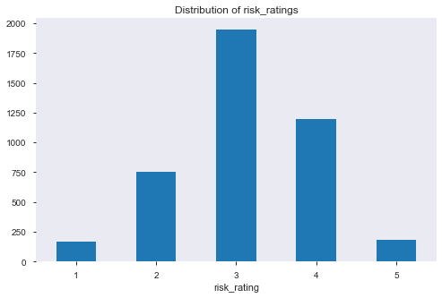

```python
#! python get_data.py

df = pd.read_csv('data/input/aml.csv', sep=',')
df.groupby('risk_rating')['user_id'].count().plot(kind='bar',
                                                  figsize=(8, 5),
                                                  grid=False,
                                                  rot=0,
                                                  title='Distribution of risk_ratings');
```

## Strategies

First, we relax the rating problem from 1 to 5 to a binary classification :

- 0 being a customer with no risk of money laundering
- 1 showing a high risk customer

```python
df.loc[df['risk_rating'] >= 4, 'risk_score'] = 1
df.loc[df['risk_rating'] <= 3, 'risk_score'] = 0
```

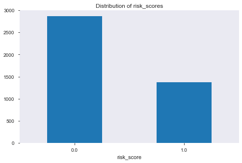

```python
df.groupby('risk_score')['user_id'].count().plot(kind='bar',
                                                 figsize=(8, 5),
                                                 grid=False,
                                                 rot=0,
                                                 title='Distribution of risk_scores');
```

## Adding features

In order to improve our training, we add features build on existing ones :

- `active_days_by_month`
- `bet_active_days`
- `ratio_dep_wd`
- `ratio_nb_bets_transactions`

```python
df['active_days_by_month'] = df['active_days'] / df['seniority'].replace(0, 1)
df['bet_active_days'] = df['nb_bets'] / df['active_days']
df['ratio_dep_wd'] = df['nb_deposits'].replace(0, 1) / df['nb_withdrawals'].replace(0, 1)
df['ratio_nb_bets_transactions'] = df['nb_bets'].replace(0, 1) / (df['nb_deposits'].replace(0, 1) + df['nb_withdrawals'].replace(0, 1))
```

## Adding new data

To enrich our dataset and reduce the AML suspicious bias, we decided to cut off the 1, 2, 3 rated customers from our annotated database to replace it by random active customers.

```python
#! python get_new_data.py

df_new_customer = pd.read_csv('data/input/aml_new_customer_2.csv', sep=',')
df_new_customer = df_new_customer.sample(n=4360, random_state=42).reset_index(drop=True)
```

```python
df_new_customer['active_days_by_month'] = df_new_customer['active_days'] / df_new_customer['seniority'].replace(0, 1)
df_new_customer['bet_active_days'] = df_new_customer['nb_bets'] / df_new_customer['active_days']
df_new_customer['ratio_dep_wd'] = df_new_customer['nb_deposits'].replace(0, 1) / df_new_customer['nb_withdrawals'].replace(0, 1)
df_new_customer['ratio_nb_bets_transactions'] = df_new_customer['nb_bets'].replace(0, 1) / (df_new_customer['nb_deposits'].replace(0, 1) + df_new_customer['nb_withdrawals'].replace(0, 1))
df_new_customer.loc[df_new_customer['risk_rating'] >= 4, 'risk_score'] = 1
df_new_customer.loc[df_new_customer['risk_rating'] <= 3, 'risk_score'] = 0
```

```python
df_reduced = df[~(df['risk_rating']<=3)].copy()
df_tot = df_reduced.append(df_new_customer, sort=False)
df_tot = df_tot.reset_index(drop=True)
```

New low/high risk customer distribution :

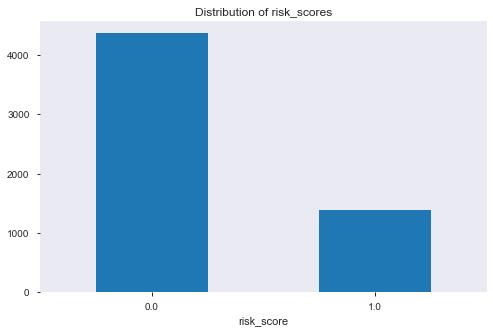

```python
df_tot.groupby('risk_score')['user_id'].count().plot(kind='bar',
                                                     figsize=(8, 5),
                                                     grid=False,
                                                     rot=0,
                                                     title='Distribution of risk_scores');
```

Here is the average difference of each features between low anf high risk customers (order by ratio) :

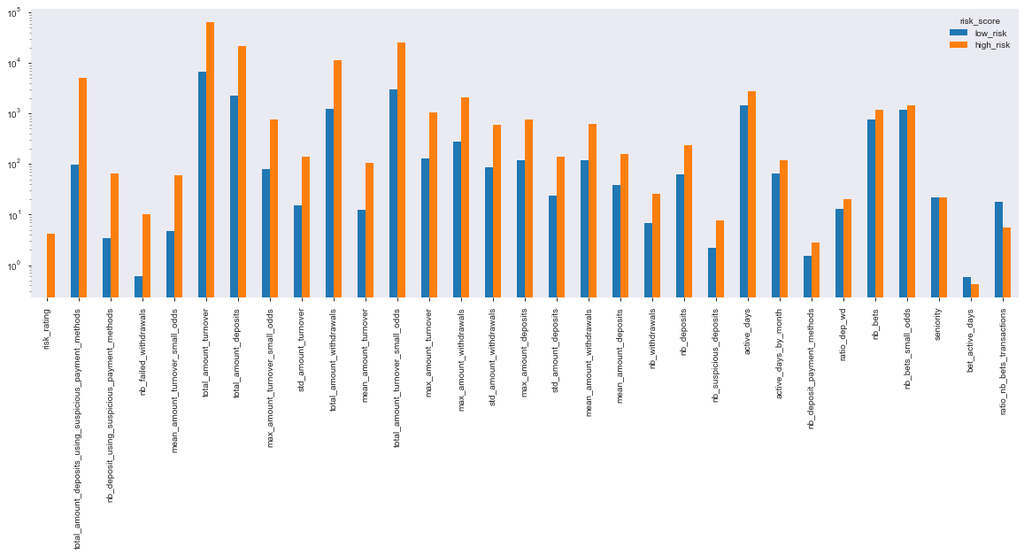

```python
feature_mean = df_tot[list(set(df).difference({'customer_sk',
                                'user_id'}))].groupby('risk_score').mean().T.rename(columns={0.0: "low_risk",
                                                                                             1.0: "high_risk"})
feature_mean['diff'] = feature_mean['high_risk'] / feature_mean['low_risk']
feature_mean = feature_mean.sort_values(by='diff', ascending=False)
feature_mean[['low_risk', 'high_risk']].plot(kind='bar',
                                             legend=True,
                                             grid=False,
                                             figsize=(20, 6))
plt.yscale('log')
```

## Quick EDA with `pandas_profiling`

We can provide you this EDA (available in htlm).

```python
# profile = df.profile_report(title='Pandas Profiling Report')
# profile.to_file(output_file="data/output/data_report.html")
```

# Classification

We train our model on all available features, removing useless info like :

- `user_id`
- `customer_sk`

And obviously the taget `risk_score` and this highly correlated `risk_rating`

```python
X_tot = df_tot[list(set(df_tot).difference({'user_id', 'customer_sk', 'risk_rating', 'risk_score'}))]
X_tot = X_tot.fillna(0)
y_tot = df_tot['risk_score']
```

To score our model, we split our data in train test set :

```python
X_tot_train, X_tot_test, y_tot_train, y_tot_test = train_test_split(X_tot,
                                                                    y_tot,
                                                                    test_size=0.2,
                                                                    random_state=42)
```

Now we can run our training on train data :

```python
forest_tot = ExtraTreesClassifier(n_estimators=250,
                                  random_state=42)
forest_tot.fit(X_tot_train, y_tot_train);
```

Our score is very satisfying :

```python
sc.score(y_tot_test, forest_tot.predict(X_tot_test))
```

```
{'confusion_matrix': {'tn': 814, 'fp': 39, 'fn': 64, 'tp': 231},
 'recall_score': 78.31,
 'precision_score': 85.56,
 'accuracy_score': 91.03}
```

Furthermore, we can improve our score by choosing a lower threshold of predicted segment choice probability:

```python
dict_score = {}

for treshold in np.arange(0, 1, 0.05):
    treshold_round = np.round(treshold, 2)
    tmp = sc.score(y_tot_test, np.asarray([1 if x[1]> treshold_round else 0 for x in forest_tot.predict_proba(X_tot_test)]))
    dict_score[treshold_round] = {}
    dict_score[treshold_round]['recall'] = tmp['recall_score']
    dict_score[treshold_round]['precision'] = tmp['precision_score']
```

These thresholds variations lead us to this graph :

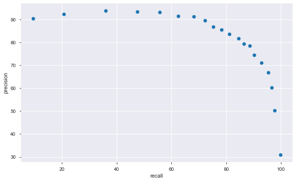

```python
x = pd.DataFrame.from_dict(dict_score).T.recall
y = pd.DataFrame.from_dict(dict_score).T.precision
plt.figure(figsize=(10, 6))
plt.scatter(x, y)
plt.xlabel("recall")
plt.ylabel("precision")
plt.show()
```

Our threshold choice will be set at `0.4` :

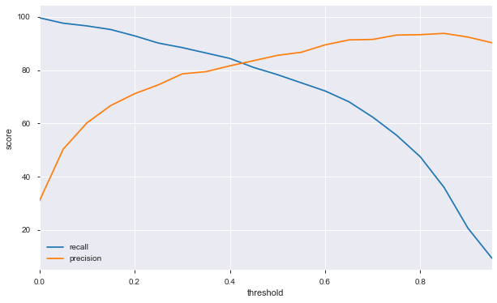

```python
pd.DataFrame.from_dict(dict_score).T.plot(figsize=(10, 6))
plt.xlabel("threshold")
plt.ylabel("score")
plt.show();
```

```python
sc.score(y_tot_test, np.asarray([1 if x[1]> 0.4 else 0 for x in forest_tot.predict_proba(X_tot_test)]))
```

```
{'confusion_matrix': {'tn': 797, 'fp': 56, 'fn': 46, 'tp': 249},
 'recall_score': 84.41,
 'precision_score': 81.64,
 'accuracy_score': 91.11}
```

## Top n result

```python
df_top_result = X_tot_test.copy()
df_top_result['predicted_risk_score'] = np.asarray([x[1] for x in forest_tot.predict_proba(X_tot_test)])
df_top_result = pd.merge(df_top_result,
                         y_tot_test,
                         how='left',
                         left_index=True,
                         right_index=True)
```

Top 100 results ordered by prediction proba :

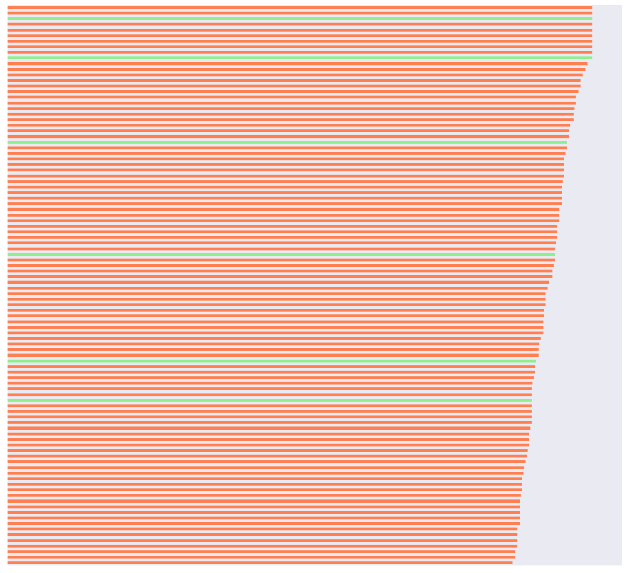

```python
df_top_100_result = df_top_result[['predicted_risk_score', 'risk_score']].sort_values(by='predicted_risk_score',
                                                                                      ascending=True).tail(100)
df_top_100_result[['predicted_risk_score']].plot(kind='barh',
                                                 figsize=(16, 15),
                                                 legend=False,
                                                 grid=False,
                                                 color=[np.where(df_top_100_result["risk_score"]==1, 'coral', 'lightgreen')])
plt.xticks([])
plt.yticks([]);
```

```python
df_top_100_result.groupby('risk_score').count()
```

| risk_score | predicted_risk_score |
| --- | --- |
| 0.0 | 6 |
| 1.0 | 94 |

Top 1000 results ordered by prediction proba :

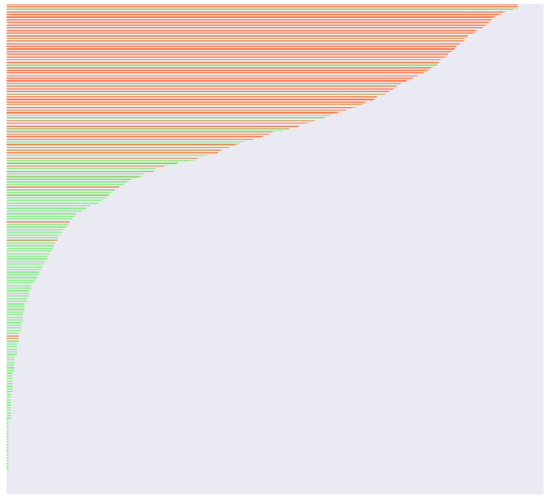

```python
df_top_1000_result = df_top_result[['predicted_risk_score', 'risk_score']].sort_values(by='predicted_risk_score',
                                                                                      ascending=True).tail(1000)
# df_top_100_result.groupby('risk_score').count()
df_top_1000_result[['predicted_risk_score']].plot(kind='barh',
                                                 figsize=(16, 15),
                                                 legend=False,
                                                 grid=False,
                                                 color=[np.where(df_top_1000_result["risk_score"]==1, 'coral', 'lightgreen')])
plt.xticks([])
plt.yticks([]);
```

## Feature importance

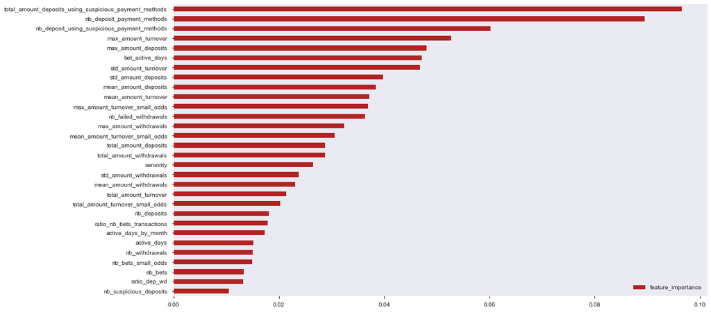

```python
pd.Series(dict(zip(X_tot.columns,
                   forest_tot.feature_importances_))).to_frame(name='feature_importance').sort_values(by='feature_importance',
                                                                                                      ascending=True).plot(kind='barh',
                                                                                                                           color='firebrick',
                                                                                                                           figsize=(16, 9),
                                                                                                                           grid=False)
figure = plt.gcf()
```

### Other experiments : Clustering

To increase our volume of data, we apply a clustering and check if we have clusters with a rich concentration of high risk customers. Infortunatly, this methode gives us two possibles results:

- we detect a tiny part of our hight risk customer and, among those detected, we are 50% confident about our prediction.
- we detect the large majority of our high risk clients, but we are 40% confident about our prediction and almost 78% of all customers are considered as suspicious.

| Clustering |  |
| --- | --- |
| confusion_matrix | 'tn': 101, 'fp': 356, 'fn': 59, 'tp': 229 |
| recall_score | 50.81 |
| precision_score | 51.14 |
| accuracy_score | 44.3 |

**Those results are not satisfying, in my opinion we should not dig this way.**